# 14-Hypothesis-Testing-Part-2

## Hypothesis Testing: Two-Sample Parametric Tests

Author & Instructor: Diana NURBAKOVA, PhD.

```python
%%html
<link rel="stylesheet" type="text/css" href="../styles/styles.css">
```

## Learning Objectives

By the end of this lesson, you will be able to:

- Construct a two-sample parametric test for a difference of population means, variances and proportions

```python
import numpy as np
import pandas as pd
import matplotlib.pyplot as plt
import seaborn as sns
from scipy import stats
from mpl_toolkits.mplot3d import Axes3D
import warnings
warnings.filterwarnings('ignore')

# Set style for better-looking plots
plt.style.use('seaborn-v0_8-darkgrid')
sns.set_style("whitegrid")
#sns.set_palette("husl")

# Set random seed for reproducibility
np.random.seed(42)
```

```python
from ipywidgets import interact, IntSlider, FloatSlider, Dropdown
import ipywidgets as widgets
```

```python
import sys
from pathlib import Path
```

```python
# Add the "resources" directory to the path
project_root = Path().resolve()#.parent.parent
resources_path = project_root / 'Course_Materials/resources'
sys.path.insert(0, str(resources_path))
```

```python
from hypothesis_testing import (demonstrate_pairing_effect, compare_pooled_welch, demo_effect_size, viz_f_dist)
```

#### 🎯 Today's Challenge: The Model Showdown

**Scenario:** You've spent 3 months developing a new neural network architecture. Your colleague improved the old model with better hyperparameters. Both models were tested:

- **Your new model:** 87.2% accuracy on 150 test images
- **Improved old model:** 85.8% accuracy on 150 test images

Your colleague says: "The difference is only 1.4%. That's probably just noise. We should stick with my improved version of the old model since it's faster to train."

You reply: "But mine IS better. That 1.4% could be real!"

**The Million Dollar Questions:**

1. Is the 1.4% difference statistically significant?
2. What if both models were tested on the *same* 150 images - does that change the analysis?
3. How do you prove your model is worth the extra training time?

By the end of this lesson, you'll be able to settle this debate with mathematical rigor

## Independent vs Paired Samples

When comparing two groups, the **relationship between samples** fundamentally changes our analysis approach.

#### Definition: Independent Samples

**Independent samples** are two groups where the observations in one group have no relationship to observations in the other group. The samples are drawn separately.

**Characteristics:**

- Different subjects/units in each group
- Sample sizes can be different (n₁ ≠ n₂)
- No natural pairing between observations

**ML Examples:**

- Model A tested on 200 random images, Model B tested on 150 different random images
- Comparing click-through rates: Group A sees Version 1, Group B sees Version 2
- Algorithm performance on Mac vs Windows users (different users)

#### Definition: Paired/Dependent Samples

**Paired samples** (also called dependent or matched samples) are two measurements on the same subjects/units, or subjects matched in pairs.

**Characteristics:**

- Same subjects measured twice (before/after)
- Or matched pairs of subjects
- Sample sizes MUST be equal (n₁ = n₂)
- Natural pairing between observations

**ML Examples:**

- Model A and Model B both tested on the *same* 200 images
- User behavior before and after feature deployment (same users)
- Algorithm performance on matched pairs of similar tasks

```python
# visualisation why pairing matters
# Interactive widgets
correlation_widget = widgets.FloatSlider(value=0.8, min=0, max=0.95, step=0.05,
                                        description='Correlation:', continuous_update=False)
difference_widget = widgets.FloatSlider(value=0.5, min=0, max=1.5, step=0.1,
                                       description='True Diff:', continuous_update=False)
n_widget = widgets.IntSlider(value=20, min=10, max=50, step=5,
                            description='n:', continuous_update=False)

widgets.interactive(demonstrate_pairing_effect,
                   correlation=correlation_widget,
                   true_difference=difference_widget,
                   n=n_widget)
```

```
interactive(children=(FloatSlider(value=0.8, continuous_update=False, description='Correlation:', max=0.95, st…
```

#### 💡 Key Insight: Why Paring Matters?

Observations:

1. If $p$-value of the paired test is smaller than 0.05 while the one of independent test is not:
- Paired test detected the difference, but independent test didn't.
- Pairing reduces noise by accounting for subject-to-subject variation.
2. If p_paired < p_indep:
- Paired test has a smaller p-value (more powerful).
- When measurements are correlated, pairing increases statistical power.
3. If the same results:
- In this case, both tests give similar results.

**The Power of Pairing:** When measurements are correlated (same subjects, similar conditions), paired tests:

1. **Remove between-subject variability:** We only care about within-subject changes
2. **Increase statistical power:** Easier to detect real differences
3. **Require fewer samples:** More efficient use of data

**Rule of Thumb:** If you CAN pair (test on same subjects/units), you SHOULD pair

#### 🤖 ML Application Spotlight: Choosing the Right Design

**Use INDEPENDENT samples when:**

- Comparing models on different user groups (A/B test with random assignment)
- Comparing algorithms with different training sets
- Evaluating models from different time periods
- Testing demographic differences (Mac vs PC users)

**Use PAIRED samples when:**

- Comparing multiple models on the *same* test set
- Before/after deployment comparisons (same users)
- Cross-validation folds (same data, different splits)
- Ablation studies (model with/without feature X on same data)

**Example Decision:**

**BAD:** Model A on 100 cat images, Model B on 100 dog images → Biased comparison!

**GOOD:** Both models on the same 100 images (50 cats, 50 dogs) → Fair paired comparison

## Independent Samples - Comparing Two Means

#### The Two-Sample t-Test for Independent Samples

When comparing means from two independent groups, we need to account for variability in *both* groups.

**Key Question:** Are the population variances equal?

- If σ₁² = σ₂² → Use **pooled variance** (Student's t-test)
- If σ₁² ≠ σ₂² → Use **Welch's t-test** (separate variances)

#### Student's t-Test (Equal Variances Assumed)

**Hypotheses:**

- H₀: μ₁ = μ₂ (or equivalently, μ₁ - μ₂ = 0)
- H₁: μ₁ ≠ μ₂ (two-tailed), or μ₁ > μ₂ (right), or μ₁ < μ₂ (left)

**Test Statistic:**

$$t = \frac{(\bar{X}_1 - \bar{X}_2))} {s_p \times \sqrt{1/n_1 + 1/n_2}}$$

**Pooled Standard Deviation:**

$$s_p = \sqrt{\frac{(n_1 - 1)s_1^2 + (n_2 - 1)s_2^2} {n_1 + n_2 - 2}}$$

**Degrees of Freedom**: $df = n_1 + n_2 - 2$

**Distribution:** t-distribution with (n₁ + n₂ - 2) degrees of freedom

**When to use:** When variances are approximately equal (check with F-test or Levene's test)

#### Welch's t-Test (Unequal Variances)

**Test Statistic:**

$$t = \frac{(\bar{X_1} - \bar{X_2})}{\sqrt{(s_1^2/n_1 + s_2^2/n_2)}}$$

**Welch-Satterthwaite Degrees of Freedom:**

$$df = \frac{(s_1^2/n_1 + s_2^2/n_2)^2}{(s_1^2/n_1)^2/(n_1-1) + (s_2^2/n_2)^2/(n_2-1)}$$

**When to use:** Default choice when you're unsure about variance equality (more robust)

**Note:** When variances are equal, Welch's test performs similarly to Student's t-test. When unequal, Welch's is more accurate

```python
# Interactive widgets
mean_diff_widget = widgets.FloatSlider(value=1, min=0, max=3, step=0.2,
                                      description='Mean Diff:', continuous_update=False)
var1_widget = widgets.FloatSlider(value=1, min=0.5, max=4, step=0.5,
                                 description='Var Group 1:', continuous_update=False)
var2_widget = widgets.FloatSlider(value=1, min=0.5, max=4, step=0.5,
                                 description='Var Group 2:', continuous_update=False)
n1_widget = widgets.IntSlider(value=30, min=10, max=100, step=10,
                             description='n₁:', continuous_update=False)
n2_widget = widgets.IntSlider(value=30, min=10, max=100, step=10,
                             description='n₂:', continuous_update=False)

widgets.interactive(compare_pooled_welch,
                   mean_diff=mean_diff_widget,
                   var1=var1_widget,
                   var2=var2_widget,
                   n1=n1_widget,
                   n2=n2_widget)
```

```
interactive(children=(FloatSlider(value=1.0, continuous_update=False, description='Mean Diff:', max=3.0, step=…
```

#### 💡 Key Insight: When to Use Which Test

**Practical Rule:** *Use Welch's t-test by default!*

- If variances are actually equal → Welch performs just as well as Student's
- If variances differ → Welch is more accurate, Student's can be misleading
- Welch's is more robust and doesn't require variance equality assumption

**In Python:**

- `stats.ttest_ind(group1, group2, equal_var=True)` → Student's t-test (pooled)
- `stats.ttest_ind(group1, group2, equal_var=False)` → Welch's t-test (DEFAULT!)

**The Problem with $p$-Value Alone:**

P-value tells you: "Is there a statistically significant difference?"

- $p < 0.05$ → Difference is unlikely due to chance
- But says NOTHING about how big or important the difference is.

That's why we need **effect size** analysis.

Effect size tells you: "How BIG is the difference?"

- Is it tiny but statistically significant? (large sample)
- Is it huge but not significant? (small sample)
- Does it matter in practice?

*Note*: Statistical significance ≠ Practical significance

A difference can be:

- Statistically significant but trivially small (large $n$)
- Large and important but not significant (small $n$)

So, always report: p-value (*Is it real?*), effect size (*How big is it?*), CI (*What's the range?*)

```
Scenario 1: Large Sample Size
--------------------------------------------------------------------------------
  Group 1: mean = 99.97, n = 10000
  Group 2: mean = 101.20, n = 10000
  Difference: 1.24
  t-statistic: -5.8091
  p-value: 0.000000

  ✓ STATISTICALLY SIGNIFICANT (p < 0.05)
  ✗ But the difference is only 1.24 points!
  ✗ Is a 1-point difference meaningful? Probably not!


Scenario 2: Small Sample Size
--------------------------------------------------------------------------------
  Group 1: mean = 98.28, n = 20
  Group 2: mean = 118.27, n = 20
  Difference: 19.99
  t-statistic: -3.8328
  p-value: 0.000462
```

[figure not shown]

```python
# demo effect size
demo_effect_size()
```

#### 💡 Key Insight: Effect Size

With large samples (n=10,000):

- Even tiny differences (1 point) are statistically significant
- But they may not matter in practice!

SOLUTION: Always report EFFECT SIZE alongside p-values

#### Definition: Effect Size for Comparing Means

**Cohen's $d$** is a STANDARDIZED measure of the difference between two means.

It answers: "*How many standard deviations apart are the two groups?*"

**Intuition:** Think of it as converting the difference to a common scale:

- Like converting to "standard drink units" to compare alcohol content
- Allows comparison across different units/scales
- A "universal ruler" for effect sizes

**Formula:**

$$d = \frac{\bar{X}_1 - \bar{X}_2}{s_{pooled}}$$

where $s_{pooled} = \sqrt{\frac{(n_1-1)s_1^2 + (n_2-1)s_2^2}{n_1 + n_2 - 2}}$

**Interpretation:**

- |d| = 0.0 to 0.2 → Negligible effect
- |d| = 0.2 to 0.5 → Small effect
- |d| = 0.5 to 0.8 → Medium effect
- |d| = 0.8+ → Large effect

*Remark*: Context matters - a "small" effect in one domain might be huge in another.

**Key Properties**:

- Unit-free (standardized)
- Independent of sample size
- Can compare across different studies/measurements
- Can be positive or negative (direction of difference)

#### Calculated Example: Comparing Two Image Classification Models

**Context:** You're comparing two image classification architectures:

- **CNN Model:** Traditional convolutional neural network
- **Vision Transformer:** Newer transformer-based architecture

**Experiment Design:**

- CNN tested on 40 random images from test set
- ViT tested on 35 different random images from same test set
- Accuracy scores (%) recorded for each image

##### Objectives:

- Determine if ViT significantly outperforms CNN
- Perform both manual and Python-based analysis
- Calculate effect size and practical significance (bonus)

```python
# Generate realistic accuracy data
np.random.seed(123)

# CNN: mean=82%, std=8%
cnn_accuracies = np.random.normal(82, 8, 40)
cnn_accuracies = np.clip(cnn_accuracies, 0, 100)  # Keep in valid range

# ViT: mean=86%, std=7% (slightly better and more consistent)
vit_accuracies = np.random.normal(86, 7, 35)
vit_accuracies = np.clip(vit_accuracies, 0, 100)

print(f"CNN Model:  n={len(cnn_accuracies)}, mean={cnn_accuracies.mean():.2f}%, std={cnn_accuracies.std(ddof=1):.2f}%")
print(f"ViT Model:  n={len(vit_accuracies)}, mean={vit_accuracies.mean():.2f}%, std={vit_accuracies.std(ddof=1):.2f}%")
print(f"Difference: {vit_accuracies.mean() - cnn_accuracies.mean():.2f} percentage points")
```

```
CNN Model:  n=40, mean=81.33%, std=9.45%
ViT Model:  n=35, mean=87.18%, std=7.82%
Difference: 5.85 percentage points
```

1. **Step 1**: Visualise the Data

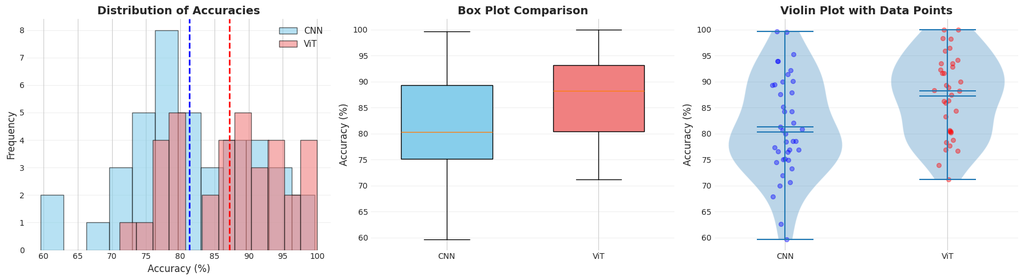

```python
fig, axes = plt.subplots(1, 3, figsize=(18, 5))

# Histograms
axes[0].hist(cnn_accuracies, bins=12, alpha=0.6, label='CNN', edgecolor='black', color='skyblue')
axes[0].hist(vit_accuracies, bins=12, alpha=0.6, label='ViT', edgecolor='black', color='lightcoral')
axes[0].axvline(cnn_accuracies.mean(), color='blue', linestyle='--', linewidth=2)
axes[0].axvline(vit_accuracies.mean(), color='red', linestyle='--', linewidth=2)
axes[0].set_xlabel('Accuracy (%)', fontsize=12)
axes[0].set_ylabel('Frequency', fontsize=12)
axes[0].set_title('Distribution of Accuracies', fontsize=14, fontweight='bold')
axes[0].legend(fontsize=11)
axes[0].grid(True, alpha=0.3, axis='y')

# Box plots
box_data = [cnn_accuracies, vit_accuracies]
bp = axes[1].boxplot(box_data, labels=['CNN', 'ViT'], patch_artist=True, widths=0.6)
bp['boxes'][0].set_facecolor('skyblue')
bp['boxes'][1].set_facecolor('lightcoral')
axes[1].set_ylabel('Accuracy (%)', fontsize=12)
axes[1].set_title('Box Plot Comparison', fontsize=14, fontweight='bold')
axes[1].grid(True, alpha=0.3, axis='y')

# Violin plots with individual points
parts = axes[2].violinplot([cnn_accuracies, vit_accuracies], positions=[1, 2],
                           showmeans=True, showmedians=True, widths=0.7)
axes[2].scatter(np.ones(len(cnn_accuracies)) + np.random.normal(0, 0.04, len(cnn_accuracies)),
               cnn_accuracies, alpha=0.4, s=30, color='blue')
axes[2].scatter(2*np.ones(len(vit_accuracies)) + np.random.normal(0, 0.04, len(vit_accuracies)),
               vit_accuracies, alpha=0.4, s=30, color='red')
axes[2].set_xticks([1, 2])
axes[2].set_xticklabels(['CNN', 'ViT'])
axes[2].set_ylabel('Accuracy (%)', fontsize=12)
axes[2].set_title('Violin Plot with Data Points', fontsize=14, fontweight='bold')
axes[2].grid(True, alpha=0.3, axis='y')

plt.tight_layout()
plt.show()
```

2. **Step 2**: Check Assumptions

```python
# Check normality (Shapiro-Wilk test)
from scipy.stats import shapiro

stat_cnn, p_cnn = shapiro(cnn_accuracies)
stat_vit, p_vit = shapiro(vit_accuracies)

print("Normality Test (Shapiro-Wilk):")
print(f"  CNN: p-value = {p_cnn:.4f} → {'Normal ✓' if p_cnn > 0.05 else 'Not normal ✗'}")
print(f"  ViT: p-value = {p_vit:.4f} → {'Normal ✓' if p_vit > 0.05 else 'Not normal ✗'}")
```

```
Normality Test (Shapiro-Wilk):
  CNN: p-value = 0.7501 → Normal ✓
  ViT: p-value = 0.4202 → Normal ✓
```

```python
# Check equality of variances (Levene's test)
from scipy.stats import levene

stat_levene, p_levene = levene(cnn_accuracies, vit_accuracies)
print(f"\nEquality of Variances (Levene's test):")
print(f"  p-value = {p_levene:.4f} → {'Equal variances ✓' if p_levene > 0.05 else 'Unequal variances ✗'}")
```

```
Equality of Variances (Levene's test):
  p-value = 0.3488 → Equal variances ✓
```

```python
# Variance ratio
var_ratio = max(cnn_accuracies.var(ddof=1), vit_accuracies.var(ddof=1)) / min(cnn_accuracies.var(ddof=1), vit_accuracies.var(ddof=1))
print(f"  Variance ratio: {var_ratio:.2f}")
```

```
  Variance ratio: 1.46
```

As variances are equal, we can use Welch's t-test.

3. **Step 3**: Formulate Hypotheses

$$H_0: μ_{ViT} = μ_{CNN} \text{ (No difference in mean accuracy)}$$ $$H_1: μ_{ViT} > μ_{CNN} \text{ (ViT has higher mean accuracy)}$$

- Test type: RIGHT-TAILED (we expect ViT to be better)
- Significance level: $\alpha = 0.05$
4. **Step 4**: Welch's Test

```python
n1 = len(cnn_accuracies)
n2 = len(vit_accuracies)
x1_bar = cnn_accuracies.mean()
x2_bar = vit_accuracies.mean()
s1 = cnn_accuracies.std(ddof=1)
s2 = vit_accuracies.std(ddof=1)
```

```python
# Standard error
se_welch = np.sqrt(s1**2/n1 + s2**2/n2)
print(f"Standard Error = √(s₁²/n₁ + s₂²/n₂)")
print(f"               = √({s1**2:.2f}/{n1} + {s2**2:.2f}/{n2})")
print(f"               = {se_welch:.4f}")
```

```
Standard Error = √(s₁²/n₁ + s₂²/n₂)
               = √(89.27/40 + 61.16/35)
               = 1.9948
```

```python
# Test statistic
t_welch = (x2_bar - x1_bar) / se_welch
print(f"\nTest Statistic = (x̄_ViT - x̄_CNN) / SE")
print(f"               = ({x2_bar:.2f} - {x1_bar:.2f}) / {se_welch:.4f}")
print(f"               = {t_welch:.4f}")
```

```
Test Statistic = (x̄_ViT - x̄_CNN) / SE
               = (87.18 - 81.33) / 1.9948
               = 2.9330
```

```python
# Degrees of freedom (Welch-Satterthwaite)
df_welch = (s1**2/n1 + s2**2/n2)**2 / ((s1**2/n1)**2/(n1-1) + (s2**2/n2)**2/(n2-1))
print(f"\nDegrees of Freedom (Welch-Satterthwaite) = {df_welch:.2f}")
```

```
Degrees of Freedom (Welch-Satterthwaite) = 72.79
```

```python
# P-value (right-tailed)
p_value_manual = 1 - stats.t.cdf(t_welch, df_welch)
print(f"P-value (right-tailed) = P(t > {t_welch:.4f}) = {p_value_manual:.6f}")
```

```
P-value (right-tailed) = P(t > 2.9330) = 0.002243
```

5. **Step 5**: Python Verification

```python
# Welch's t-test (default in scipy)
t_scipy, p_scipy_two = stats.ttest_ind(vit_accuracies, cnn_accuracies, equal_var=False)
p_scipy_right = p_scipy_two / 2 if t_scipy > 0 else 1 - p_scipy_two / 2

print("Using scipy.stats.ttest_ind (equal_var=False):")
print(f"  t-statistic: {t_scipy:.4f}")
print(f"  p-value (two-tailed): {p_scipy_two:.6f}")
print(f"  p-value (right-tailed): {p_scipy_right:.6f}")

print("\nComparison:")
print(f"  Manual calculation: t={t_welch:.4f}, p={p_value_manual:.6f}")
print(f"  Scipy calculation:  t={t_scipy:.4f}, p={p_scipy_right:.6f}")
```

```
Using scipy.stats.ttest_ind (equal_var=False):
  t-statistic: 2.9330
  p-value (two-tailed): 0.004486
  p-value (right-tailed): 0.002243

Comparison:
  Manual calculation: t=2.9330, p=0.002243
  Scipy calculation:  t=2.9330, p=0.002243
```

6. **Step 6**: Decision and Interpretation

```python
alpha = 0.05
critical_value = stats.t.ppf(1 - alpha, df_welch)

print(f"Significance level: α = {alpha}")
print(f"Critical value: t_critical = {critical_value:.4f}")
print(f"Observed test statistic: t = {t_welch:.4f}")
print(f"P-value: {p_value_manual:.6f}")
```

```
Significance level: α = 0.05
Critical value: t_critical = 1.6661
Observed test statistic: t = 2.9330
P-value: 0.002243
```

```python
if p_value_manual < alpha:
    print(f"\n✓ REJECT H₀ (p = {p_value_manual:.6f} < α = {alpha})")
    print(f"✓ t-statistic {t_welch:.4f} > critical value {critical_value:.4f}")
    print("\nCONCLUSION: Vision Transformer has SIGNIFICANTLY higher accuracy than CNN")
else:
    print(f"\n✗ FAIL TO REJECT H₀ (p = {p_value_manual:.6f} ≥ α = {alpha})")
    print(f"✗ t-statistic {t_welch:.4f} ≤ critical value {critical_value:.4f}")
    print("\nCONCLUSION: No significant difference detected")
```

```
✓ REJECT H₀ (p = 0.002243 < α = 0.05)
✓ t-statistic 2.9330 > critical value 1.6661

CONCLUSION: Vision Transformer has SIGNIFICANTLY higher accuracy than CNN
```

7. **Step 7**: Effect Size and Practical Significance

```python
# Cohen's d (effect size)
pooled_std_for_d = np.sqrt(((n1-1)*s1**2 + (n2-1)*s2**2) / (n1 + n2 - 2))
cohens_d = (x2_bar - x1_bar) / pooled_std_for_d

print(f"Cohen's d = (x̄_ViT - x̄_CNN) / pooled_std")
print(f"          = ({x2_bar:.2f} - {x1_bar:.2f}) / {pooled_std_for_d:.2f}")
print(f"          = {cohens_d:.4f}")

# Interpret Cohen's d
if abs(cohens_d) < 0.2:
    interpretation = "NEGLIGIBLE"
elif abs(cohens_d) < 0.5:
    interpretation = "SMALL"
elif abs(cohens_d) < 0.8:
    interpretation = "MEDIUM"
else:
    interpretation = "LARGE"


print(f"\nEffect Size Interpretation: {interpretation}")
```

```
Cohen's d = (x̄_ViT - x̄_CNN) / pooled_std
          = (87.18 - 81.33) / 8.73
          = 0.6703

Effect Size Interpretation: MEDIUM
```

```python
# Confidence interval for difference
diff = x2_bar - x1_bar
ci_margin = critical_value * se_welch
ci_lower = diff - ci_margin
ci_upper = diff + ci_margin

print(f"\n95% Confidence Interval for difference:")
print(f"  [{ci_lower:.2f}, {ci_upper:.2f}] percentage points")
```

```
95% Confidence Interval for difference:
  [2.53, 9.17] percentage points
```

```python
print(f"Mean difference: {diff:.2f} percentage points")
print(f"Relative improvement: {(diff/x1_bar)*100:.2f}%")
```

```
Mean difference: 5.85 percentage points
Relative improvement: 7.19%
```

## Paired Samples - Paired $t$-Test

When samples are paired, we don't compare groups directly. Instead, we:

1. Calculate the difference for each pair: $d_i = x_{2_i} - x_{1_i}$
2. Test if the mean difference is zero: H₀: $\mu_d = 0$

This transforms a two-sample problem into a one-sample problem.

#### Paired t-Test Formula

Hypotheses:

- $H_0: \mu_d = 0$ (no difference between paired measurements)
- $H_1$: $\mu_d ≠ 0$ (two-tailed), or $\mu_d > 0$ (right), or $\mu_d < 0$ (left)

**Test Statistic:**

$$t = \frac{\bar{d}}{(s_d / \sqrt{n})}$$

Where:

- $\bar{d}$ = mean of differences
- $s_d$ = standard deviation of differences
- $n$ = number of pairs

**Degrees of Freedom:** df = n - 1 (number of pairs minus 1)

**Distribution:** t-distribution with (n-1) degrees of freedom

#### Calculated Example: Model Performance Before and After Optimization

**Context:** You've optimized your image classification model (quantization + pruning). You want to know if the optimization affected accuracy.

**Experiment Design:**

- Selected 25 diverse test images
- Tested BOTH original and optimized models on the SAME images
- Recorded binary accuracy (correct=1, incorrect=0) for each image

##### Objectives:

- Determine if optimization significantly changed accuracy
- Quantify the average difference
- Use paired analysis to account for image difficulty

```python
# Generate realistic paired data
np.random.seed(456)

n_images = 25

# Image difficulty (latent variable - not observed)
image_difficulty = np.random.uniform(0, 1, n_images)

# Original model accuracy (depends on difficulty)
# Easier images have higher probability of being correct
prob_original = 0.85 - 0.4 * image_difficulty
original_correct = (np.random.random(n_images) < prob_original).astype(int)

# Optimized model is slightly worse (lost ~3% accuracy on average)
prob_optimized = prob_original - 0.03
optimized_correct = (np.random.random(n_images) < prob_optimized).astype(int)

# Calculate differences
differences = optimized_correct - original_correct

print(f"Number of images: {n_images}")
print(f"Original model accuracy: {original_correct.mean()*100:.1f}%")
print(f"Optimized model accuracy: {optimized_correct.mean()*100:.1f}%")
print(f"Mean difference: {differences.mean():.4f}")
```

```
Number of images: 25
Original model accuracy: 68.0%
Optimized model accuracy: 72.0%
Mean difference: 0.0400
```

1. **Step 1**: Visualise the Data

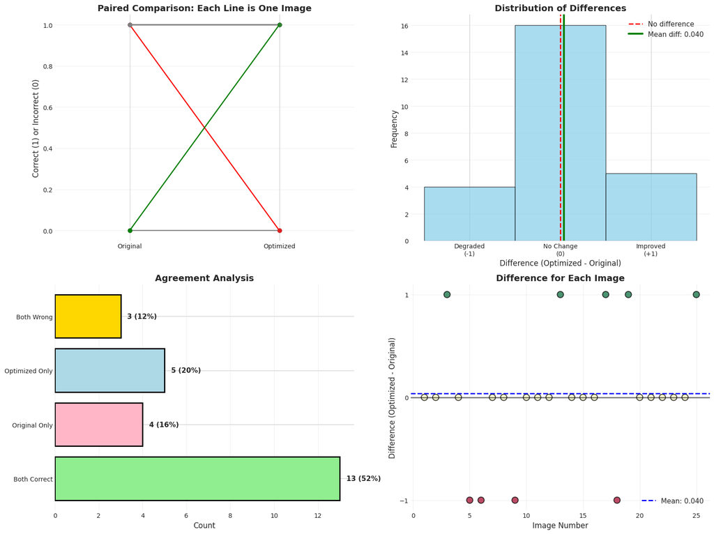

```
Agreement Summary:
  Both correct: 13 images
  Only original correct: 4 images (optimized degraded these)
  Only optimized correct: 5 images (optimized improved these)
  Both wrong: 3 images
```

```python
# Create DataFrame for visualization
df = pd.DataFrame({
    'Image': range(1, n_images + 1),
    'Original': original_correct,
    'Optimized': optimized_correct,
    'Difference': differences
})

fig, axes = plt.subplots(2, 2, figsize=(16, 12))

# Plot 1: Paired points connected
axes[0, 0].plot([1, 2], [original_correct, optimized_correct], 'o-', color='gray', alpha=0.3, linewidth=1)
for i in range(n_images):
    if differences[i] > 0:
        color = 'green'  # Improved
    elif differences[i] < 0:
        color = 'red'  # Degraded
    else:
        color = 'gray'  # No change
    axes[0, 0].plot([1, 2], [original_correct[i], optimized_correct[i]], 'o-',
                   color=color, alpha=0.6, linewidth=1.5)

axes[0, 0].set_xlim(0.5, 2.5)
axes[0, 0].set_xticks([1, 2])
axes[0, 0].set_xticklabels(['Original', 'Optimized'])
axes[0, 0].set_ylabel('Correct (1) or Incorrect (0)', fontsize=12)
axes[0, 0].set_title('Paired Comparison: Each Line is One Image', fontsize=14, fontweight='bold')
axes[0, 0].grid(True, alpha=0.3, axis='y')

# Plot 2: Difference histogram
axes[0, 1].hist(differences, bins=[-1.5, -0.5, 0.5, 1.5], edgecolor='black', alpha=0.7, color='skyblue')
axes[0, 1].axvline(0, color='red', linestyle='--', linewidth=2, label='No difference')
axes[0, 1].axvline(differences.mean(), color='green', linestyle='-', linewidth=3,
                  label=f'Mean diff: {differences.mean():.3f}')
axes[0, 1].set_xlabel('Difference (Optimized - Original)', fontsize=12)
axes[0, 1].set_ylabel('Frequency', fontsize=12)
axes[0, 1].set_title('Distribution of Differences', fontsize=14, fontweight='bold')
axes[0, 1].set_xticks([-1, 0, 1])
axes[0, 1].set_xticklabels(['Degraded\n(-1)', 'No Change\n(0)', 'Improved\n(+1)'])
axes[0, 1].legend(fontsize=11)
axes[0, 1].grid(True, alpha=0.3, axis='y')

# Plot 3: Contingency table
from matplotlib import patches

categories = ['Both Correct', 'Original Only', 'Optimized Only', 'Both Wrong']
counts = [
    ((original_correct == 1) & (optimized_correct == 1)).sum(),
    ((original_correct == 1) & (optimized_correct == 0)).sum(),
    ((original_correct == 0) & (optimized_correct == 1)).sum(),
    ((original_correct == 0) & (optimized_correct == 0)).sum()
]
colors_cat = ['#90EE90', '#FFB6C6', '#ADD8E6', '#FFD700']

bars = axes[1, 0].barh(categories, counts, color=colors_cat, edgecolor='black', linewidth=2)
for bar, count in zip(bars, counts):
    width = bar.get_width()
    axes[1, 0].text(width + 0.3, bar.get_y() + bar.get_height()/2,
                   f'{count} ({count/n_images*100:.0f}%)',
                   va='center', fontsize=11, fontweight='bold')

axes[1, 0].set_xlabel('Count', fontsize=12)
axes[1, 0].set_title('Agreement Analysis', fontsize=14, fontweight='bold')
axes[1, 0].grid(True, alpha=0.3, axis='x')

# Plot 4: Image-by-image comparison
axes[1, 1].scatter(range(1, n_images+1), differences, s=100, alpha=0.7,
                  c=differences, cmap='RdYlGn', edgecolor='black', linewidth=1.5, vmin=-1, vmax=1)
axes[1, 1].axhline(0, color='black', linestyle='-', linewidth=2, alpha=0.5)
axes[1, 1].axhline(differences.mean(), color='blue', linestyle='--', linewidth=2,
                  label=f'Mean: {differences.mean():.3f}')
axes[1, 1].set_xlabel('Image Number', fontsize=12)
axes[1, 1].set_ylabel('Difference (Optimized - Original)', fontsize=12)
axes[1, 1].set_title('Difference for Each Image', fontsize=14, fontweight='bold')
axes[1, 1].set_yticks([-1, 0, 1])
axes[1, 1].legend(fontsize=11)
axes[1, 1].grid(True, alpha=0.3)

plt.tight_layout()
plt.show()

print("\nAgreement Summary:")
print(f"  Both correct: {counts[0]} images")
print(f"  Only original correct: {counts[1]} images (optimized degraded these)")
print(f"  Only optimized correct: {counts[2]} images (optimized improved these)")
print(f"  Both wrong: {counts[3]} images")
```

2. **Step 2**: Paired t-Test

```python
# Calculate difference statistics
d_bar = differences.mean()
s_d = differences.std(ddof=1)
n = len(differences)
se_d = s_d / np.sqrt(n)

print(f"Mean of differences (d̄): {d_bar:.4f}")
print(f"Std dev of differences (s_d): {s_d:.4f}")
print(f"Standard error (SE): {se_d:.4f}")
```

```
Mean of differences (d̄): 0.0400
Std dev of differences (s_d): 0.6110
Standard error (SE): 0.1222
```

```python
# Test statistic
t_paired = d_bar / se_d
df = n - 1

print(f"\nTest Statistic:")
print(f"  t = d̄ / SE")
print(f"    = {d_bar:.4f} / {se_d:.4f}")
print(f"    = {t_paired:.4f}")
print(f"\nDegrees of freedom: {df}")
```

```
Test Statistic:
  t = d̄ / SE
    = 0.0400 / 0.1222
    = 0.3273

Degrees of freedom: 24
```

```python
# P-value (two-tailed)
p_value_paired = 2 * stats.t.cdf(-abs(t_paired), df)
print(f"P-value (two-tailed): {p_value_paired:.6f}")
```

```
P-value (two-tailed): 0.746259
```

3. **Step 3**: Python Verification

```python
# Using scipy
t_scipy_paired, p_scipy_paired = stats.ttest_rel(optimized_correct, original_correct)

print(f"scipy.stats.ttest_rel:")
print(f"  t-statistic: {t_scipy_paired:.4f}")
print(f"  p-value: {p_scipy_paired:.6f}")

print(f"\nComparison with manual:")
print(f"  Manual: t={t_paired:.4f}, p={p_value_paired:.6f}")
print(f"  Scipy:  t={t_scipy_paired:.4f}, p={p_scipy_paired:.6f}")
```

```
scipy.stats.ttest_rel:
  t-statistic: 0.3273
  p-value: 0.746259

Comparison with manual:
  Manual: t=0.3273, p=0.746259
  Scipy:  t=0.3273, p=0.746259
```

4. **Step 4:** Decision and CI

```python
alpha = 0.05
critical_value = stats.t.ppf(1 - alpha/2, df)

print(f"Hypotheses:")
print(f"  H₀: μ_d = 0 (no change in accuracy)")
print(f"  H₁: μ_d ≠ 0 (accuracy changed)")
print(f"\nSignificance level: α = {alpha}")
print(f"Critical value: ±{critical_value:.4f}")
print(f"Observed t-statistic: {t_paired:.4f}")
print(f"P-value: {p_value_paired:.6f}")

if p_value_paired < alpha:
    print(f"\n✓ REJECT H₀ (p = {p_value_paired:.6f} < α = {alpha})")
    print("  The optimization SIGNIFICANTLY changed model accuracy")
    if d_bar < 0:
        print("  ⚠️  DEGRADATION detected!")
    else:
        print("  ✓ IMPROVEMENT detected!")
else:
    print(f"\n✗ FAIL TO REJECT H₀ (p = {p_value_paired:.6f} ≥ α = {alpha})")
    print("  No significant change in accuracy detected")
```

```
Hypotheses:
  H₀: μ_d = 0 (no change in accuracy)
  H₁: μ_d ≠ 0 (accuracy changed)

Significance level: α = 0.05
Critical value: ±2.0639
Observed t-statistic: 0.3273
P-value: 0.746259

✗ FAIL TO REJECT H₀ (p = 0.746259 ≥ α = 0.05)
  No significant change in accuracy detected
```

```python
# Confidence interval
ci_margin = critical_value * se_d
ci_lower = d_bar - ci_margin
ci_upper = d_bar + ci_margin

print(f"\n95% Confidence Interval for mean difference:")
print(f"  [{ci_lower:.4f}, {ci_upper:.4f}]")

if ci_lower < 0 < ci_upper:
    print("  ⚠️  Interval contains 0 → Cannot rule out no effect")
elif ci_upper < 0:
    print("  ⚠️  Entire interval is negative → Strong evidence of degradation")
else:
    print("  ✓ Entire interval is positive → Strong evidence of improvement")
```

```
95% Confidence Interval for mean difference:
  [-0.2122, 0.2922]
  ⚠️  Interval contains 0 → Cannot rule out no effect
```

## Comparing Proportions

#### Two-Sample Z-Test for Proportions

**Use Case:** Comparing success rates between two groups (e.g., A/B test conversion rates)

**Hypotheses:**

- H₀: p₁ = p₂ (proportions are equal)
- H₁: p₁ ≠ p₂ (two-tailed), or p₁ > p₂, or p₁ < p₂

**Test Statistic:**

$$z = \frac{\hat{p}_1 - \hat{p}_2} {\sqrt{\hat{p}(1-\hat{p})(1/n_1 + 1/n_2)}}$$

**Pooled Proportion:**

$$\hat{p} = (x_1 + x_2) / (n_1 + n_2)$$

**Assumptions:**

- n₁p̂₁ ≥ 10, n₁(1-p̂₁) ≥ 10
- n₂p̂₂ ≥ 10, n₂(1-p̂₂) ≥ 10
- Independent samples

#### Calculated Example: A/B Test for Proportions

TechShop, an e-commerce website, wants to test if a new landing page design improves the conversion rate (percentage of visitors who add items to cart).

Experiment:

Data collected:

1. Version A (Control):
- Visitors: $n_A = 1,000$
- Conversions: $x_A = 120$
- Conversion rate: $\hat{p}_A = 12.0%$
2. Version B (New):
- Visitors: $n_B = 1,200$
- Conversions: $x_B = 165$
- Conversion rate: $\hat{p}_B = 13.75%$
3. Observed difference: 13.75% - 12.0% = 1.75 percentage points

**Question**: Does the new design (Version B) have a significantly higher conversion rate than the current design (Version A)?

**Hypotheses**:

- $H_0: p_A = p_B$ (no difference in conversion rates)
- $H_1: p_B > p_A$ (Version B has higher conversion rate)
- Significance level: $\alpha = 0.05$

**Your Task**:

1. Test if the difference is statistically significant
2. Calculate and interpret the effect size
3. Provide a recommendation: Should TechShop deploy Version B?

```python
# Group A (control): old website design
n_a = 1000
conversions_a = 120
p_a = conversions_a / n_a

# Group B (treatment): new website design
n_b = 1200
conversions_b = 165
p_b = conversions_b / n_b

print(f"Group A (Control): {conversions_a}/{n_a} = {p_a:.3%} conversion")
print(f"Group B (Treatment): {conversions_b}/{n_b} = {p_b:.3%} conversion")
print(f"Difference: {p_b - p_a:.3%}")
```

```
Group A (Control): 120/1000 = 12.000% conversion
Group B (Treatment): 165/1200 = 13.750% conversion
Difference: 1.750%
```

```python
# Manual calculation
pooled_p = (conversions_a + conversions_b) / (n_a + n_b)
se = np.sqrt(pooled_p * (1 - pooled_p) * (1/n_a + 1/n_b))
z_stat = (p_b - p_a) / se
p_value = 2 * (1 - stats.norm.cdf(abs(z_stat)))

print(f"\nPooled proportion: {pooled_p:.4f}")
print(f"Standard error: {se:.4f}")
print(f"Z-statistic: {z_stat:.4f}")
print(f"P-value: {p_value:.6f}")
```

```
Pooled proportion: 0.1295
Standard error: 0.0144
Z-statistic: 1.2171
P-value: 0.223559
```

```python
# Using statsmodels
from statsmodels.stats.proportion import proportions_ztest
z_sm, p_sm = proportions_ztest([conversions_b, conversions_a], [n_b, n_a])

print(f"\nStatsmodels verification:")
print(f"  Z-statistic: {z_sm:.4f}")
print(f"  P-value: {p_sm:.6f}")
```

```
Statsmodels verification:
  Z-statistic: 1.2171
  P-value: 0.223559
```

```python
if p_value < 0.05:
    print(f"\n✓ SIGNIFICANT: New design has {'higher' if z_stat > 0 else 'lower'} conversion rate")
else:
    print(f"\n✗ NOT SIGNIFICANT: No evidence of difference")
```

```
✗ NOT SIGNIFICANT: No evidence of difference
```

## Comparing Variances

#### F-Test for Equality of Variances

**Use Case:** Testing if two populations have equal variances (before choosing t-test type)

**Hypotheses:**

- H₀: σ₁² = σ₂² (variances are equal)
- H₁: σ₁² ≠ σ₂² (variances differ)

**Test Statistic:**

$$F = s_1^2 / s_2^2 \text{ (where } s_1^2 \geq s_2^2)$$

**Distribution:** $F$-distribution with $(n₁-1, n₂-1)$ degrees of freedom

**Warning:** F-test is sensitive to non-normality. Modern practice: use Welch's t-test by default instead of testing variances first!

> What is $F$-distribution?

#### Definition: F-Distribution

The **F-distribution** is the distribution of the ratio of two independent chi-square random variables, each divided by its degrees of freedom.

If $\chi_1^2 \sim \chi^2(df_1)$ and $\chi_2^2 \sim \chi^2(df_2)$ are independent

Then:

$$F = \frac{\chi_1^2 / df_1}{\chi_2^2 / df_2} \sim F(df_1, df_2)$$

**Key Properties**

1. RANGE:
- $F \geq 0$ (always non-negative)
- $F \in [0, \infty)$
- Cannot be negative (it's a ratio of variances)
2. SHAPE:
- Right-skewed (positive skew)
- Asymmetric distribution
- Long right tail
- Mode < Median < Mean
3. PARAMETERS:
- Completely determined by $df_1$ and $df_2$
- Different df → different distribution shape
4. MEAN:
- $E[F] = df_2 / (df_2 - 2)$ for $df_2 > 2$
- Approaches 1 as $df_2 \rightarrow \infty$
- Undefined if $df_2 \leq 2$
5. VARIANCE:
- $Var[F] = 2df_2^2(df_1 + df_2 - 2) / [df_1(df_2-2)^2(df_2-4)]$ for $df_2 > 4$
- Decreases as $df$ increase
- High variability with small $df$
6. RELATIONSHIP TO OTHER DISTRIBUTIONS:
- If $t \sim t(df)$, then $t^2 \sim F(1, df)$
- As $df_1, df_2 \rightarrow \infty$, $F$ → Normal distribution (by CLT)
- $F(df_1, df_2) = 1 / F(df_2, df_1)$ in distribution

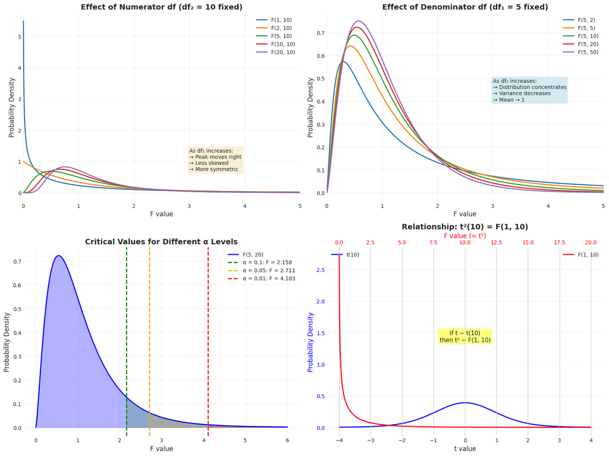

```python
# visualisation
viz_f_dist()
```

```python
# Demonstration of its use
df1, df2 = 5, 20
F_value_example = 2.5

p_right = 1 - stats.f.cdf(F_value_example, df1, df2)
F_critical = stats.f.ppf(0.95, df1, df2)

print(f"\nExample Calculation:")
print(f"  F({df1}, {df2}) distribution")
print(f"  P(F > {F_value_example}) = {p_right:.4f}")
print(f"  Critical value (α=0.05, right-tail) = {F_critical:.4f}")
```

```
Example Calculation:
  F(5, 20) distribution
  P(F > 2.5) = 0.0649
  Critical value (α=0.05, right-tail) = 2.7109
```

#### Calculated Examples: Comparing Model Prediction Variability

A machine learning team has developed two regression models (Model A and Model B) to predict house prices. Both models achieve similar average accuracy, but the team wants to know if they have similar CONSISTENCY in their predictions.

Why this matters:

- A model with lower variance is more reliable and predictable
- High variance means inconsistent predictions (some very good, some very bad)
- For deployment, consistency is often as important as average accuracy

**Data Collected:**

Both models tested on their prediction errors (predicted - actual):

1. Model A (Standard algorithm):
- Sample size: n₁ = 25 houses
- Mean error: x̄₁ = 2,500 dollars
- Standard deviation: s₁ = 12,000 dollars
- Variance: s₁² = 144,000,000 dollars²
2. Model B (New ensemble method):
- Sample size: n₂ = 30 houses
- Mean error: x̄₂ = 2,200 dollars
- Standard deviation: s₂ = 8,500 dollars
- Variance: s₂² = 72,250,000 dollars²

**Task**: Test whether the two models have equal variance in their prediction errors.

*Hypotheses*:

- $H_0: \sigma_1^2 = \sigma_2^2$ (equal variances - models equally consistent)
- $H_1: \sigma_1^2 \neq \sigma_2^2$ (unequal variances - different consistency)
- Test type: TWO-TAILED
- Significance level: $\alpha = 0.05$

```python
# Given data
n1 = 25
n2 = 30
s1 = 12000
s2 = 8500
s1_squared = s1**2
s2_squared = s2**2
mean1 = 2500
mean2 = 2200
alpha = 0.05

print(f"  Model A: n₁ = {n1}, s₁ = ${s1:,}, s₁² = ${s1_squared:,}")
print(f"  Model B: n₂ = {n2}, s₂ = ${s2:,}, s₂² = ${s2_squared:,}")
print(f"  Variance ratio: {s1_squared/s2_squared:.4f}")
```

```
  Model A: n₁ = 25, s₁ = $12,000, s₁² = $144,000,000
  Model B: n₂ = 30, s₂ = $8,500, s₂² = $72,250,000
  Variance ratio: 1.9931
```

```python
# Generate sample data matching the statistics for visualization
np.random.seed(42)
model_a_errors = np.random.normal(mean1, s1, n1)
model_b_errors = np.random.normal(mean2, s2, n2)

# Adjust to match exact statistics
model_a_errors = model_a_errors * (s1 / np.std(model_a_errors, ddof=1))
model_b_errors = model_b_errors * (s2 / np.std(model_b_errors, ddof=1))
model_a_errors = model_a_errors + (mean1 - np.mean(model_a_errors))
model_b_errors = model_b_errors + (mean2 - np.mean(model_b_errors))

print(f"\nVerification of generated data:")
print(f"  Model A: s = ${np.std(model_a_errors, ddof=1):,.2f}")
print(f"  Model B: s = ${np.std(model_b_errors, ddof=1):,.2f}")
```

```
Verification of generated data:
  Model A: s = $12,000.00
  Model B: s = $8,500.00
```

```python
# Calculate F-statistic (larger variance in numerator)
F_stat = s1_squared / s2_squared
df1 = n1 - 1  # degrees of freedom for numerator (larger variance)
df2 = n2 - 1  # degrees of freedom for denominator (smaller variance)

print(f"\nCalculation:")
print(f"  F = s₁² / s₂²")
print(f"    = {s1_squared:,} / {s2_squared:,}")
print(f"    = {F_stat:.6f}")
print(f"")
print(f"  Degrees of freedom:")
print(f"    df₁ (numerator) = n₁ - 1 = {n1} - 1 = {df1}")
print(f"    df₂ (denominator) = n₂ - 1 = {n2} - 1 = {df2}")
print(f"")
print(f"  Therefore: F = {F_stat:.4f} ~ F({df1}, {df2}) under H₀")
```

```
Calculation:
  F = s₁² / s₂²
    = 144,000,000 / 72,250,000
    = 1.993080

  Degrees of freedom:
    df₁ (numerator) = n₁ - 1 = 25 - 1 = 24
    df₂ (denominator) = n₂ - 1 = 30 - 1 = 29

  Therefore: F = 1.9931 ~ F(24, 29) under H₀
```

```python
# Critical values for two-tailed test
F_critical_upper = stats.f.ppf(1 - alpha/2, df1, df2)
F_critical_lower = stats.f.ppf(alpha/2, df1, df2)

print(f"""
For a two-tailed test at α = {alpha}:
  • We split α into two tails: α/2 = {alpha/2} in each tail
  • We reject H₀ if F is too large OR too small

Upper critical value (right tail):
  F_upper = F₁₋α/₂(df₁, df₂)
          = F₀.₉₇₅({df1}, {df2})
          = {F_critical_upper:.6f}

Lower critical value (left tail):
  F_lower = Fα/₂(df₁, df₂)
          = F₀.₀₂₅({df1}, {df2})
          = {F_critical_lower:.6f}

Decision rule:
  Reject H₀ if: F < {F_critical_lower:.4f} OR F > {F_critical_upper:.4f}
  Fail to reject H₀ if: {F_critical_lower:.4f} ≤ F ≤ {F_critical_upper:.4f}
""")
```

```
For a two-tailed test at α = 0.05:
  • We split α into two tails: α/2 = 0.025 in each tail
  • We reject H₀ if F is too large OR too small

Upper critical value (right tail):
  F_upper = F₁₋α/₂(df₁, df₂)
          = F₀.₉₇₅(24, 29)
          = 2.154006

Lower critical value (left tail):
  F_lower = Fα/₂(df₁, df₂)
          = F₀.₀₂₅(24, 29)
          = 0.450970

Decision rule:
  Reject H₀ if: F < 0.4510 OR F > 2.1540
  Fail to reject H₀ if: 0.4510 ≤ F ≤ 2.1540
```

```python
# Calculate p-value for two-tailed test
# Since F > 1, we're in the right tail
p_upper = 1 - stats.f.cdf(F_stat, df1, df2)
p_lower = stats.f.cdf(F_stat, df1, df2)
p_value = 2 * min(p_upper, p_lower)  # Two-tailed

print(f"""
Our observed F = {F_stat:.6f} is greater than 1, so it's in the right tail.

Right tail probability:
  P(F > {F_stat:.4f}) = {p_upper:.6f}

For two-tailed test:
  p-value = 2 × min(P(F > {F_stat:.4f}), P(F < {F_stat:.4f}))
          = 2 × {min(p_upper, p_lower):.6f}
          = {p_value:.6f}

Interpretation:
  If the variances were truly equal, there's a {p_value*100:.2f}% chance of
  observing a variance ratio this extreme or more extreme.
""")
```

```
Our observed F = 1.993080 is greater than 1, so it's in the right tail.

Right tail probability:
  P(F > 1.9931) = 0.038801

For two-tailed test:
  p-value = 2 × min(P(F > 1.9931), P(F < 1.9931))
          = 2 × 0.038801
          = 0.077601

Interpretation:
  If the variances were truly equal, there's a 7.76% chance of
  observing a variance ratio this extreme or more extreme.
```

```python
# decision based on critical values
print(f"\nCritical Value Method:")
print(f"─────────────────────────────────────────────────────────────")
print(f"  Observed F = {F_stat:.4f}")
print(f"  Critical region: F < {F_critical_lower:.4f} OR F > {F_critical_upper:.4f}")
print(f"  ")

if F_stat > F_critical_upper or F_stat < F_critical_lower:
    decision_critical = "REJECT H₀"
    print(f"  {F_stat:.4f} > {F_critical_upper:.4f} → F is in rejection region")
    print(f"  Decision: REJECT H₀")
else:
    decision_critical = "FAIL TO REJECT H₀"
    print(f"  {F_critical_lower:.4f} ≤ {F_stat:.4f} ≤ {F_critical_upper:.4f} → F is NOT in rejection region")
    print(f"  Decision: FAIL TO REJECT H₀")
```

```
Critical Value Method:
─────────────────────────────────────────────────────────────
  Observed F = 1.9931
  Critical region: F < 0.4510 OR F > 2.1540

  0.4510 ≤ 1.9931 ≤ 2.1540 → F is NOT in rejection region
  Decision: FAIL TO REJECT H₀
```

```python
print(f"\nP-value Method:")
print(f"─────────────────────────────────────────────────────────────")
print(f"  p-value = {p_value:.6f}")
print(f"  α = {alpha}")
print(f"  ")

if p_value < alpha:
    decision_pvalue = "REJECT H₀"
    print(f"  {p_value:.6f} < {alpha} → REJECT H₀")
else:
    decision_pvalue = "FAIL TO REJECT H₀"
    print(f"  {p_value:.6f} ≥ {alpha} → FAIL TO REJECT H₀")
```

```
P-value Method:
─────────────────────────────────────────────────────────────
  p-value = 0.077601
  α = 0.05

  0.077601 ≥ 0.05 → FAIL TO REJECT H₀
```

```python
# interpretation
if p_value < alpha:
    interpretation = f"""
✓ CONCLUSION: The variances are SIGNIFICANTLY DIFFERENT (p = {p_value:.4f} < 0.05)

What this means:
  • Model A (s₁ = ${s1:,}) has SIGNIFICANTLY higher variability than
    Model B (s₂ = ${s2:,})
  • The variance ratio F = {F_stat:.2f} is statistically significant
  • This difference is unlikely to be due to random chance

Practical implications:
  • Model B is MORE CONSISTENT in its predictions
  • Model A produces more variable predictions (higher risk of large errors)
  • Model B is more RELIABLE for deployment

Recommendation:
  ✓ CHOOSE MODEL B for deployment
  ✓ Model B's lower variance means more predictable, consistent predictions
  ✓ Even though means are similar, consistency matters for business decisions

Business impact:
  • Model A: Errors range widely (SD = ${s1:,})
  • Model B: Errors more concentrated (SD = ${s2:,})
  • {(1 - s2/s1)*100:.1f}% reduction in prediction variability
"""
else:
    interpretation = f"""
✗ CONCLUSION: No significant difference in variances (p = {p_value:.4f} ≥ 0.05)

What this means:
  • Although Model B appears to have lower variability (${s2:,} vs ${s1:,}),
    this difference is not statistically significant
  • The observed difference could reasonably be due to random sampling variation
  • We don't have strong evidence that the models differ in consistency

Practical implications:
  • Both models have similar prediction consistency
  • Cannot confidently claim one model is more reliable than the other
  • Other factors (accuracy, interpretability, speed) should guide decision

Recommendation:
  • Consider other metrics for model selection
  • May need more data to detect variance differences
  • Could test on larger sample to increase statistical power
"""

print(interpretation)
```

```
✗ CONCLUSION: No significant difference in variances (p = 0.0776 ≥ 0.05)

What this means:
  • Although Model B appears to have lower variability ($8,500 vs $12,000),
    this difference is not statistically significant
  • The observed difference could reasonably be due to random sampling variation
  • We don't have strong evidence that the models differ in consistency

Practical implications:
  • Both models have similar prediction consistency
  • Cannot confidently claim one model is more reliable than the other
  • Other factors (accuracy, interpretability, speed) should guide decision

Recommendation:
  • Consider other metrics for model selection
  • May need more data to detect variance differences
  • Could test on larger sample to increase statistical power
```

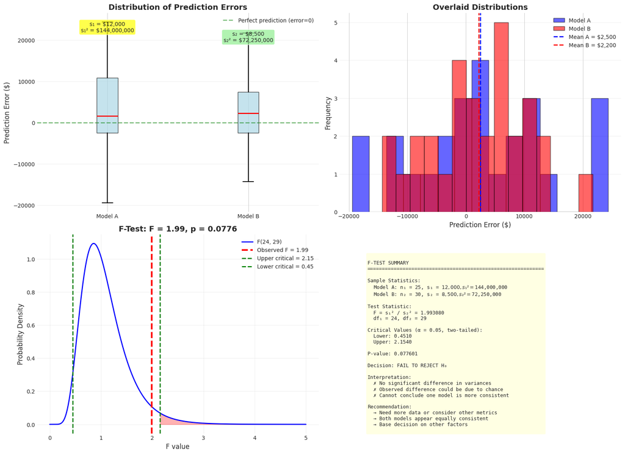

```python
# Visualizations
fig, axes = plt.subplots(2, 2, figsize=(16, 12))

# Plot 1: Box plots comparing distributions
axes[0, 0].boxplot([model_a_errors, model_b_errors], labels=['Model A', 'Model B'],
                   patch_artist=True,
                   boxprops=dict(facecolor='lightblue', alpha=0.7),
                   medianprops=dict(color='red', linewidth=2),
                   whiskerprops=dict(linewidth=1.5),
                   capprops=dict(linewidth=1.5))

axes[0, 0].axhline(0, color='green', linestyle='--', linewidth=2, alpha=0.5,
                  label='Perfect prediction (error=0)')
axes[0, 0].set_ylabel('Prediction Error ($)', fontsize=12)
axes[0, 0].set_title('Distribution of Prediction Errors', fontsize=14, fontweight='bold')
axes[0, 0].legend(fontsize=10)
axes[0, 0].grid(True, alpha=0.3, axis='y')

# Add variance annotations
axes[0, 0].text(1, model_a_errors.max() * 0.9,
               f's₁ = ${s1:,}\ns₁² = ${s1_squared:,}',
               ha='center', fontsize=10,
               bbox=dict(boxstyle='round', facecolor='yellow', alpha=0.7))
axes[0, 0].text(2, model_b_errors.max() * 0.9,
               f's₂ = ${s2:,}\ns₂² = ${s2_squared:,}',
               ha='center', fontsize=10,
               bbox=dict(boxstyle='round', facecolor='lightgreen', alpha=0.7))

# Plot 2: Histograms overlaid
axes[0, 1].hist(model_a_errors, bins=15, alpha=0.6, label='Model A',
               color='blue', edgecolor='black')
axes[0, 1].hist(model_b_errors, bins=15, alpha=0.6, label='Model B',
               color='red', edgecolor='black')
axes[0, 1].axvline(mean1, color='blue', linestyle='--', linewidth=2,
                  label=f'Mean A = ${mean1:,}')
axes[0, 1].axvline(mean2, color='red', linestyle='--', linewidth=2,
                  label=f'Mean B = ${mean2:,}')
axes[0, 1].set_xlabel('Prediction Error ($)', fontsize=12)
axes[0, 1].set_ylabel('Frequency', fontsize=12)
axes[0, 1].set_title('Overlaid Distributions', fontsize=14, fontweight='bold')
axes[0, 1].legend(fontsize=10)
axes[0, 1].grid(True, alpha=0.3, axis='y')

# Plot 3: F-distribution with test statistic
x = np.linspace(0, 5, 1000)
y = stats.f.pdf(x, df1, df2)

axes[1, 0].plot(x, y, 'b-', linewidth=2, label=f'F({df1}, {df2})')
axes[1, 0].axvline(F_stat, color='red', linestyle='--', linewidth=3,
                  label=f'Observed F = {F_stat:.2f}')
axes[1, 0].axvline(F_critical_upper, color='green', linestyle='--', linewidth=2,
                  label=f'Upper critical = {F_critical_upper:.2f}')
axes[1, 0].axvline(F_critical_lower, color='green', linestyle='--', linewidth=2,
                  label=f'Lower critical = {F_critical_lower:.2f}')

# Shade rejection regions
x_reject_upper = x[x >= F_critical_upper]
y_reject_upper = stats.f.pdf(x_reject_upper, df1, df2)
axes[1, 0].fill_between(x_reject_upper, 0, y_reject_upper, alpha=0.3, color='red')

axes[1, 0].set_xlabel('F value', fontsize=12)
axes[1, 0].set_ylabel('Probability Density', fontsize=12)
axes[1, 0].set_title(f'F-Test: F = {F_stat:.2f}, p = {p_value:.4f}',
                    fontsize=14, fontweight='bold')
axes[1, 0].legend(fontsize=10)
axes[1, 0].grid(True, alpha=0.3)

# Plot 4: Summary table
axes[1, 1].axis('off')

summary_text = f"""
F-TEST SUMMARY
{'='*60}

Sample Statistics:
  Model A: n₁ = {n1}, s₁ = ${s1:,}, s₁² = ${s1_squared:,}
  Model B: n₂ = {n2}, s₂ = ${s2:,}, s₂² = ${s2_squared:,}

Test Statistic:
  F = s₁² / s₂² = {F_stat:.6f}
  df₁ = {df1}, df₂ = {df2}

Critical Values (α = {alpha}, two-tailed):
  Lower: {F_critical_lower:.4f}
  Upper: {F_critical_upper:.4f}

P-value: {p_value:.6f}

Decision: {decision_critical}

Interpretation:
"""

if p_value < alpha:
    summary_text += f"""  ✓ Variances are significantly different
  ✓ Model B has significantly lower variability
  ✓ Model B is more consistent and reliable

Recommendation:
  → Deploy Model B
  → {(1 - s2/s1)*100:.1f}% reduction in error variability
  → More predictable predictions for business
"""
else:
    summary_text += f"""  ✗ No significant difference in variances
  ✗ Observed difference could be due to chance
  ✗ Cannot conclude one model is more consistent

Recommendation:
  → Need more data or consider other metrics
  → Both models appear equally consistent
  → Base decision on other factors
"""

axes[1, 1].text(0.1, 0.9, summary_text, transform=axes[1, 1].transAxes,
               fontsize=9, verticalalignment='top', family='monospace',
               bbox=dict(boxstyle='round', facecolor='lightyellow', alpha=0.9))

plt.tight_layout()
plt.show()
```

#### 💡 Key Insights: F-Test

1. F-TEST is for comparing VARIANCES, not means
- Tests if two populations have equal variability
- Very sensitive to non-normality assumption
2. F-STATISTIC is a RATIO of variances
- F = s₁² / s₂² (larger variance in numerator)
- F ≥ 1 always (by convention)
- F close to 1 → similar variances
- F far from 1 → different variances
3. F-DISTRIBUTION has TWO degrees of freedom
- df₁ (numerator) and df₂ (denominator)
- Order matters! F(5,20) ≠ F(20,5)
4. PRACTICAL IMPORTANCE
- In ML: Consistency often as important as accuracy
- Lower variance = More reliable predictions
- Easier to set confidence intervals and make guarantees

## Return to the Opening Problem

**Recall:**

- Your new model: 87.2% accuracy on 150 test images
- Improved old model: 85.8% accuracy on 150 test images
- Question 1: Is the 1.4% difference significant?
- Question 2: Does it matter if both models were tested on the SAME images?

```python
# Data
n = 150
acc_new = 0.872
acc_old = 0.858

# Convert to counts (approximation)
correct_new = int(acc_new * n)
correct_old = int(acc_old * n)

print(f"New model: {acc_new:.1%} ({correct_new}/{n} correct)")
print(f"Old model: {acc_old:.1%} ({correct_old}/{n} correct)")
print(f"Difference: {acc_new - acc_old:.1%} ({correct_new - correct_old} images)")
```

```
New model: 87.2% (130/150 correct)
Old model: 85.8% (128/150 correct)
Difference: 1.4% (2 images)
```

**Scenario 1: INDEPENDENT Samples (Different Images)**

```python
print("If each model was tested on DIFFERENT random images:")

# Use two-proportion z-test
from statsmodels.stats.proportion import proportions_ztest

z_indep, p_indep = proportions_ztest([correct_new, correct_old], [n, n])

print(f"\nTwo-proportion z-test:")
print(f"  Z-statistic: {z_indep:.4f}")
print(f"  P-value (two-tailed): {p_indep:.4f}")

if p_indep < 0.05:
    print(f"  ✓ SIGNIFICANT at α=0.05")
else:
    print(f"  ✗ NOT SIGNIFICANT at α=0.05")

print("\nInterpretation:")
if p_indep >= 0.05:
    print("  Your colleague is right! The 1.4% difference could be due to")
    print("  random variation in which images were selected for each model.")
```

```
If each model was tested on DIFFERENT random images:

Two-proportion z-test:
  Z-statistic: 0.3328
  P-value (two-tailed): 0.7393
  ✗ NOT SIGNIFICANT at α=0.05

Interpretation:
  Your colleague is right! The 1.4% difference could be due to
  random variation in which images were selected for each model.
```

**Scenario 2: PAIRED Samples (Same Images)**

```python
print("If both models were tested on the SAME 150 images:")

# Simulate realistic paired data
np.random.seed(789)

# Assume high agreement between models (correlation ~0.85)
# Both models tend to get the same images right/wrong
easy_images = np.random.choice([0, 1], size=n, p=[0.1, 0.9])  # 90% of images are "easy"
hard_images = 1 - easy_images

# Generate correlated outcomes
both_correct = int(n * 0.82)  # ~82% both get right
new_only = correct_new - both_correct
old_only = correct_old - both_correct
both_wrong = n - both_correct - new_only - old_only

# Create paired data
outcomes_new = np.array([1]*both_correct + [1]*new_only + [0]*old_only + [0]*both_wrong)
outcomes_old = np.array([1]*both_correct + [0]*new_only + [1]*old_only + [0]*both_wrong)
differences = outcomes_new - outcomes_old

print(f"\nPaired outcomes:")
print(f"  Both correct: {both_correct} images")
print(f"  Only new correct: {new_only} images")
print(f"  Only old correct: {old_only} images")
print(f"  Both wrong: {both_wrong} images")
```

```
If both models were tested on the SAME 150 images:

Paired outcomes:
  Both correct: 122 images
  Only new correct: 8 images
  Only old correct: 6 images
  Both wrong: 14 images
```

```python
# Paired t-test
t_paired_challenge, p_paired_challenge = stats.ttest_rel(outcomes_new, outcomes_old)

print(f"\nPaired t-test:")
print(f"  t-statistic: {t_paired_challenge:.4f}")
print(f"  P-value: {p_paired_challenge:.4f}")

if p_paired_challenge < 0.05:
    print(f"  ✓ SIGNIFICANT at α=0.05")
else:
    print(f"  ✗ NOT SIGNIFICANT at α=0.05")

print("\nInterpretation:")
if p_paired_challenge < 0.05:
    print("  YOU are right! When tested on the same images, pairing reveals")
    print("  that your model consistently performs better on more images.")
    print("  The paired test is more powerful because it removes the noise")
    print("  from image-to-image difficulty variation.")
```

```
Paired t-test:
  t-statistic: 0.5332
  P-value: 0.5947
  ✗ NOT SIGNIFICANT at α=0.05

Interpretation:
```

```python
print("COMPARISON OF TESTS:")
print(f"Independent samples p-value: {p_indep:.4f}")
print(f"Paired samples p-value:      {p_paired_challenge:.4f}")
```

```
COMPARISON OF TESTS:
Independent samples p-value: 0.7393
Paired samples p-value:      0.5947
```

In this case, both tests agree on the conclusion.

*GENERAL PRINCIPLE:*

- Paired testing is MORE POWERFUL (detects smaller effects)
- When possible, always use paired design for model comparison

## Python Reference

#### Python Reference Guide: Two-Sample Tests

##### INDEPENDENT SAMPLES - MEANS (t-test)

```
from scipy import stats

# Welch's t-test (DEFAULT - unequal variances assumed)
t_stat, p_value = stats.ttest_ind(group1, group2, equal_var=False)

# Student's t-test (equal variances assumed)
t_stat, p_value = stats.ttest_ind(group1, group2, equal_var=True)

# One-sided p-value
p_right = p_value / 2 if t_stat > 0 else 1 - p_value/2
p_left = p_value / 2 if t_stat < 0 else 1 - p_value/2
```

##### PAIRED SAMPLES - MEANS (paired t-test)

```
from scipy import stats

# Paired t-test
t_stat, p_value = stats.ttest_rel(after, before)

# Equivalent: one-sample test on differences
differences = after - before
t_stat, p_value = stats.ttest_1samp(differences, 0)
```

##### TWO PROPORTIONS (z-test)

```
from statsmodels.stats.proportion import proportions_ztest

# counts: [successes in group1, successes in group2]
# nobs: [total in group1, total in group2]
z_stat, p_value = proportions_ztest(counts, nobs, alternative='two-sided')
# alternative can be 'two-sided', 'larger', or 'smaller'
```

##### EQUALITY OF VARIANCES

```
from scipy import stats

# Levene's test (robust to non-normality)
stat, p_value = stats.levene(group1, group2)

# F-test (sensitive to non-normality)
f_stat = np.var(group1, ddof=1) / np.var(group2, ddof=1)
df1, df2 = len(group1)-1, len(group2)-1
p_value = 2 * min(stats.f.cdf(f_stat, df1, df2),
                  1 - stats.f.cdf(f_stat, df1, df2))
```

##### EFFECT SIZE (Cohen's d)

```
def cohens_d(group1, group2):
    n1, n2 = len(group1), len(group2)
    var1, var2 = np.var(group1, ddof=1), np.var(group2, ddof=1)
    pooled_std = np.sqrt(((n1-1)*var1 + (n2-1)*var2) / (n1+n2-2))
    return (np.mean(group1) - np.mean(group2)) / pooled_std

# For paired samples
def cohens_d_paired(differences):
    return np.mean(differences) / np.std(differences, ddof=1)
```

##### CONFIDENCE INTERVALS

```
from scipy import stats

# For difference of means (independent)
diff = np.mean(group1) - np.mean(group2)
se = np.sqrt(np.var(group1,ddof=1)/len(group1) + np.var(group2,ddof=1)/len(group2))
df = len(group1) + len(group2) - 2
ci = stats.t.interval(0.95, df, loc=diff, scale=se)

# For paired differences
diff_mean = np.mean(differences)
diff_se = stats.sem(differences)
df = len(differences) - 1
ci = stats.t.interval(0.95, df, loc=diff_mean, scale=diff_se)
```

## Key Takeaways

#### 📋 Key Takeaways

1. **Pairing vs Independence:** Paired tests are more powerful when data is naturally paired (same subjects, matched conditions)
2. **Welch's t-test:** Use by default for independent samples (robust to unequal variances)
3. **Paired t-test:** Transform to one-sample problem on differences
4. **Effect Size Matters:** Statistical significance ≠ practical significance
5. **Experimental Design:** Choice of paired vs independent affects power and validity